# TP4: Decision trees & random forests

## Import

```python
# If needed, uncomment the line below:

#!conda install python-graphviz

import warnings
warnings.filterwarnings("ignore")
from ipywidgets import interact
```

```python
from pylab import *
#import numpy as np
#import matplotlib.pyplot as plt
import seaborn as sns; sns.set(style="ticks", color_codes=True)

# Load the library with the iris dataset
from sklearn.datasets import load_iris, load_wine



# Load scikit's decision tree classifier
from sklearn import tree

# Load scikit's random forest classifier library
from sklearn.ensemble import RandomForestClassifier, RandomForestRegressor

# To visualize trees
import graphviz


# Load pandas to manipulate data frames (Excel like)
import pandas as pd

# Load numpy
#import numpy as np

# Set random seed
np.random.seed(0)
```

```python
iris = load_iris()
```

## Explore the data set

1. What is the structure of the object `iris` ?
2. Plot this dataset in a well chosen set of representations to explore the data.

```python
print("Type of iris:", type(iris))
```

```
Type of iris: <class 'sklearn.utils.Bunch'>
```

1. iris is a dictionary-like object, the interesting attributes are: ‘data’, the data to learn, ‘target’, the classification labels, ‘target_names’, the meaning of the labels, ‘feature_names’, the meaning of the features, ‘DESCR’, the full description of the dataset, ‘filename’, the physical location of iris csv dataset (added in version 0.20). (scikit learn)

```python
import pandas as pd

# Create a dataframe with the four feature variables
df = pd.DataFrame(iris.data, columns=iris.feature_names)

# View the top 5 rows
df.head()
```

|  | sepal length (cm) | sepal width (cm) | petal length (cm) | petal width (cm) |
| --- | --- | --- | --- | --- |
| 0 | 5.1 | 3.5 | 1.4 | 0.2 |
| 1 | 4.9 | 3.0 | 1.4 | 0.2 |
| 2 | 4.7 | 3.2 | 1.3 | 0.2 |
| 3 | 4.6 | 3.1 | 1.5 | 0.2 |
| 4 | 5.0 | 3.6 | 1.4 | 0.2 |

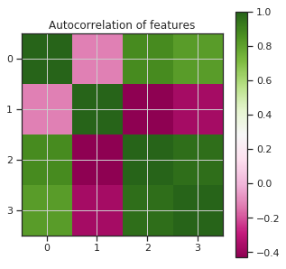

```python
correlations = df.corr()
fig = plt.figure(figsize = (5,5))
ax = fig.add_subplot(1, 1, 1)

plt.imshow(correlations,cmap='PiYG')
#plt.imshow(correlations,cmap='viridis')
plt.colorbar()
plt.grid(b=1)
plt.title("Autocorrelation of features")
a = ax.set_xticks(np.arange(correlations.shape[0]))
a = ax.set_yticks(np.arange(correlations.shape[0]))
```

The features "petal length" and "petal width" are highly correlated.

```python
# Add a new column with the species number, this is what we are going to try to predict
df['species'] = pd.Categorical.from_codes(iris.target, iris.target_names)
#df['species']=iris.target
# View the top 5 rows
df.head()
```

|  | sepal length (cm) | sepal width (cm) | petal length (cm) | petal width (cm) | species |
| --- | --- | --- | --- | --- | --- |
| 0 | 5.1 | 3.5 | 1.4 | 0.2 | setosa |
| 1 | 4.9 | 3.0 | 1.4 | 0.2 | setosa |
| 2 | 4.7 | 3.2 | 1.3 | 0.2 | setosa |
| 3 | 4.6 | 3.1 | 1.5 | 0.2 | setosa |
| 4 | 5.0 | 3.6 | 1.4 | 0.2 | setosa |

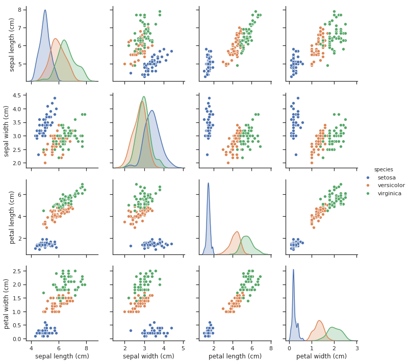

```python
g = sns.pairplot(df, hue="species")
```

```python
#df.plot.scatter(x="sepal length (cm)", y="sepal width (cm)",c="species",cmap='viridis')
#df.plot.scatter(x="sepal length (cm)", y="petal length (cm)",c="species",cmap='viridis')
#df.plot.scatter(x="sepal width (cm)", y="petal length (cm)",c="species",cmap='viridis')
#df.plot.scatter(x="petal width (cm)", y="petal length (cm)",c="species",cmap='viridis')
#plt.show()
```

The classes can be well separated by a threshold on the petal length features, and petal width.  
For example, we can draw a line for :

- petal width = 0.7 and petal width = 1.7 on the 4th plot
- petal length = 2.2 and petal length = 4.9 on the 3rd plot  
  Thus, decision trees methods seems well adapted to the problem.

## Using `pandas` to manipulate the data

Pandas is great to manipulate data in a Microsoft Excel like way.

```python
# Add a new column with the species nµames, this is what we are going to try to predict
#df['species'] = pd.Categorical.from_codes(iris.target, iris.target_names)

# View the top 5 rows
df.head()
```

|  | sepal length (cm) | sepal width (cm) | petal length (cm) | petal width (cm) | species |
| --- | --- | --- | --- | --- | --- |
| 0 | 5.1 | 3.5 | 1.4 | 0.2 | setosa |
| 1 | 4.9 | 3.0 | 1.4 | 0.2 | setosa |
| 2 | 4.7 | 3.2 | 1.3 | 0.2 | setosa |
| 3 | 4.6 | 3.1 | 1.5 | 0.2 | setosa |
| 4 | 5.0 | 3.6 | 1.4 | 0.2 | setosa |

## Step 2: create training and test sets

Create a new column that for each row, generates a random number between 0 and 1, and if that value is less than or equal to .75, then sets the value of that cell as True and false otherwise. This is a quick and dirty way of randomly assigning some rows to be used as the training data and some as the test data.

```python
df['is_train'] = np.random.uniform(0, 1, len(df)) <= .75

# View the top 5 rows
df.head()
```

|  | sepal length (cm) | sepal width (cm) | petal length (cm) | petal width (cm) | species | is_train |
| --- | --- | --- | --- | --- | --- | --- |
| 0 | 5.1 | 3.5 | 1.4 | 0.2 | setosa | True |
| 1 | 4.9 | 3.0 | 1.4 | 0.2 | setosa | False |
| 2 | 4.7 | 3.2 | 1.3 | 0.2 | setosa | True |
| 3 | 4.6 | 3.1 | 1.5 | 0.2 | setosa | True |
| 4 | 5.0 | 3.6 | 1.4 | 0.2 | setosa | True |

```python
# Create two new dataframes, one with the training rows, one with the test rows
train, test = df[df['is_train']==True], df[df['is_train']==False]
```

```python
# Show the number of observations for the test and training dataframes
print('Number of observations in the training data:', len(train))
print('Number of observations in the test data:',len(test))
```

```
Number of observations in the training data: 119
Number of observations in the test data: 31
```

```python
# Create a list of the feature column's names
features = df.columns[:4]

# View features
features
```

```
Index(['sepal length (cm)', 'sepal width (cm)', 'petal length (cm)',
       'petal width (cm)'],
      dtype='object')
```

```python
# train['species'] contains the actual species names. Before we can use it,
# we need to convert each species name into a digit. So, in this case there
# are three species, which have been coded as 0, 1, or 2.
y_train = pd.factorize(train['species'])[0]
y_test = pd.factorize(test['species'])[0]
print("Number of class in train set 0: ",len(y_train[y_train==0]))
print("Number of class in train set 1: ",len(y_train[y_train==1]))
print("Number of class in train set 2: ",len(y_train[y_train==2]))

print("Number of class in test set 0: ",len(y_test[y_test==0]))
print("Number of class in test set 1: ",len(y_test[y_test==1]))
print("Number of class in test set 2: ",len(y_test[y_test==2]))
print(y_train.shape,y_test.shape)
```

```
Number of class in train set 0:  43
Number of class in train set 1:  39
Number of class in train set 2:  37
Number of class in test set 0:  7
Number of class in test set 1:  11
Number of class in test set 2:  13
(119,) (31,)
```

We don't have a lot of data but have a quite balanced dataset. But not the same proportion of different classes between train and test set.

## Step 3: decision trees for the iris dataset

## Exercise 1

1. Train the decision tree on the iris dataset and explain how one should read blocks in `graphviz` representation of the tree.
2. Plot the regions of decision with the points of the training set superimposed.

*Indication: you may find the function `plt.contourf` useful.

```python
clf = tree.DecisionTreeClassifier()
clf = clf.fit(train[features], y_train)

# Using the whole dataset you may use directly:
#clf = clf.fit(iris.data, iris.target)
```

```python
dot_data = tree.export_graphviz(clf, out_file=None,
                         feature_names=iris.feature_names,
                         class_names=iris.target_names,
                         filled=True, rounded=True,
                         special_characters=True)
graph = graphviz.Source(dot_data)
graph
```

[figure not shown]

```python
X_pl = np.linspace(0,8,300) # petal length
Y_pw = np.linspace(0,3,300) # petal width
mean_sl = df['sepal length (cm)'].mean()
mean_sw = df['sepal width (cm)'].mean()
XX, YY= np.meshgrid(X_pl,Y_pw)
grille_2D = np.vstack((XX.flatten(),YY.flatten())).T
grille_4D = np.hstack((np.ones(grille_2D.shape)*np.r_[mean_sl,mean_sw],grille_2D))
```

```python
prediction_grille = clf.predict(grille_4D)
prediction_grille[prediction_grille==2].shape
```

```
(28080,)
```

```python
df.head()
```

|  | sepal length (cm) | sepal width (cm) | petal length (cm) | petal width (cm) | species | is_train |
| --- | --- | --- | --- | --- | --- | --- |
| 0 | 5.1 | 3.5 | 1.4 | 0.2 | setosa | True |
| 1 | 4.9 | 3.0 | 1.4 | 0.2 | setosa | False |
| 2 | 4.7 | 3.2 | 1.3 | 0.2 | setosa | True |
| 3 | 4.6 | 3.1 | 1.5 | 0.2 | setosa | True |
| 4 | 5.0 | 3.6 | 1.4 | 0.2 | setosa | True |

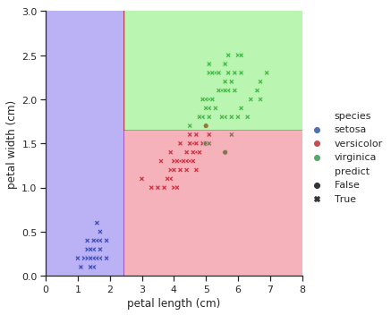

```python
df['predict'] = (clf.predict(df[features])==iris.target)

sns.relplot(data=df,x="petal length (cm)", y="petal width (cm)",hue='species',style='predict',palette=['b','r','g'], )

plt.contourf(X_pl,Y_pw,prediction_grille.reshape(300,300),cmap='brg',alpha = 0.3)
```

The main discriminant features, as we saw earlier in the plots, are the petals features. Indeed, the algorithm first separate the classes thanks to the petal width and length criteria. As expected in the previous section, the decision tree discriminate with:

```python
#We can also export the tree in Graphviz format and  save the resulting graph in an output file iris.pdf:
dot_data = tree.export_graphviz(clf, out_file=None)
graph = graphviz.Source(dot_data)
graph.render("iris")
```

```
'iris.pdf'
```

After being fitted, **the model can then be used to predict the class of samples**:

```python
class_pred_train = clf.predict(train.values[:, :4])
class_pred_test = clf.predict(test.values[:,:4])
print("Accuracy train set: ", np.sum(class_pred_train==y_train)/y_train.shape[0])
print("Accuracy test set: ", np.sum(class_pred_test==y_test)/y_test.shape[0])

#x_train.drop(columns=['species','is_train'])
#test.drop(columns=['species','is_train'])
```

```
Accuracy train set:  1.0
Accuracy test set:  0.8709677419354839
```

## Exercise 2

1. Build 2 different trees based on a sepal features (sepal lengths, sepal widths) vs petal features (petal lengths, petal widths) only: which features are the most discriminant?
2. Compare performances with those obtained using all features.
3. Try the same as above using the various splitting criterion available, Gini's index, classification error or cross-entropy. Comment on your results.

#### Only sepal featues

```python
clf = tree.DecisionTreeClassifier()
# We fit the tree with only the first two features
clf = clf.fit(train[features[:2]], y_train)
dot_data = tree.export_graphviz(clf, out_file=None,
                         feature_names=iris.feature_names[:2],
                         class_names=iris.target_names,
                         filled=True, rounded=True,
                         special_characters=True)
graph = graphviz.Source(dot_data)
graph
```

[figure not shown]

We notice that the tree is very hight, with a lot of non-significant leaves (often only 1 or 2 samples per leaves).

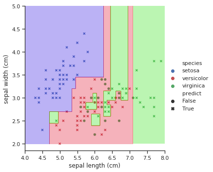

```python
X_sl = np.linspace(4,8,300) # sepal length
Y_sw = np.linspace(2,5,300) # sepal width

XX, YY= np.meshgrid(X_sl,Y_sw)
grille_2D = np.vstack((XX.flatten(),YY.flatten())).T
prediction_grille = clf.predict(grille_2D)

df['predict'] = (clf.predict(df[features[:2]])==iris.target)
sns.relplot(data=df,x="sepal length (cm)", y="sepal width (cm)",hue='species',style='predict',palette=['b','r','g'], )
plt.contourf(X_sl,Y_sw,prediction_grille.reshape(300,300),cmap='brg',alpha = 0.3)
```

When we plot the decision boundary, we see that the decisions boundary are very complex, this make sense because the tree is also very high.  
According to the bias-variance tradeoff, the classifier would probably have a high variance and a big generalisation error.  
The decision tree might overfit the datas.

```python
print("accuracy on the training set", clf.score(train[features[:2]], y_train))
print("accuracy on the  test set   ", clf.score(test[features[:2]], y_test))
```

[output not shown]

To confirm the previous results, and see the effect of the training set, we reproduce the previous experiments by bootstrapping the training set.

```
Accuracy on  train set    0.94
Accuracy on  test set    0.631578947368421
Accuracy on  train set    0.94
Accuracy on  test set    0.6578947368421053
Accuracy on  train set    0.95
Accuracy on  test set    0.631578947368421
Accuracy on  train set    0.94
Accuracy on  test set    0.6052631578947368
Accuracy on  train set    0.96
Accuracy on  test set    0.631578947368421
Accuracy on  train set    0.94
Accuracy on  test set    0.631578947368421
Accuracy on  train set    0.95
Accuracy on  test set    0.631578947368421
Accuracy on  train set    0.95
Accuracy on  test set    0.631578947368421
```

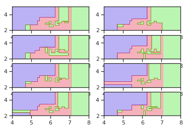

```python
for i in range(8):
    plt.subplot(4,2,i+1)
    train_sample = train.sample(100)
    y_train_sample = pd.factorize(train_sample['species'],sort='unique')[0]
    clf = tree.DecisionTreeClassifier()
    clf = clf.fit(train_sample[features[:2]], y_train_sample)
    prediction_grille = clf.predict(grille_2D)
    plt.contourf(X_sl,Y_sw,prediction_grille.reshape(300,300),cmap='brg',alpha = 0.3)
    print("Accuracy on  train set   ", clf.score(train_sample[features[:2]], y_train_sample))
    print("Accuracy on  test set   ", clf.score(test[features[:2]], y_test))
```

#### Only petal features

```python
clf = tree.DecisionTreeClassifier(criterion='entropy')
# We fit the tree with only the last two features
clf = clf.fit(train[features[2:]], y_train)
dot_data = tree.export_graphviz(clf, out_file=None,
                         feature_names=iris.feature_names[2:],
                         class_names=iris.target_names,
                         filled=True, rounded=True,
                         special_characters=True)
graph = graphviz.Source(dot_data)
graph
```

[figure not shown]

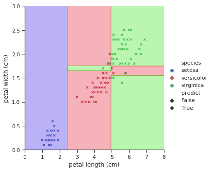

```python
X_pl = np.linspace(0,8,300) # petal length
Y_pw = np.linspace(0,3,300) # petal width

XX, YY= np.meshgrid(X_pl,Y_pw)
grille_2D = np.vstack((XX.flatten(),YY.flatten())).T
prediction_grille = clf.predict(grille_2D)

df['predict'] = (clf.predict(df[features[2:]])==iris.target)
sns.relplot(data=df,x="petal length (cm)", y="petal width (cm)",hue='species',style='predict',palette=['b','r','g'], )
plt.contourf(X_pl,Y_pw,prediction_grille.reshape(300,300),cmap='brg',alpha = 0.3)
```

Decisions boundaries are simplier than before.

```python
print("accuracy on the training set", clf.score(train[features[2:]], y_train))
print("accuracy on the  test set   ", clf.score(test[features[2:]], y_test))
```

[output not shown]

```python
len(y_train)
```

```
101
```

```
accuracy on the  test set    0.9736842105263158
accuracy on the  test set    0.868421052631579
accuracy on the  test set    0.9736842105263158
accuracy on the  test set    0.868421052631579
accuracy on the  test set    0.868421052631579
accuracy on the  test set    0.868421052631579
accuracy on the  test set    0.868421052631579
accuracy on the  test set    0.868421052631579
```

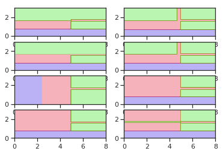

```python
for i in range(8):
    plt.subplot(4,2,i+1)
    train_sample = train.sample(100)
    y_train_sample = pd.factorize(train_sample['species'],sort='unique')[0]
    clf = tree.DecisionTreeClassifier()
    clf = clf.fit(train_sample[features[2:]], y_train_sample)
    prediction_grille = clf.predict(grille_2D)
    plt.contourf(X_pl,Y_pw,prediction_grille.reshape(300,300),cmap='brg',alpha = 0.3)
    print("accuracy on the  test set   ", clf.score(test[features[2:]], y_test))
```

#### try with other splitting criterion

###### Let's try to compare gini and cross entropy splitting criterion for some different training sets.

```
[GINI] accuracy on the  test set    0.868421052631579
[ENTR] accuracy on the  test set    0.868421052631579
[GINI] accuracy on the  test set    0.868421052631579
[ENTR] accuracy on the  test set    0.868421052631579
[GINI] accuracy on the  test set    0.868421052631579
[ENTR] accuracy on the  test set    0.868421052631579
[GINI] accuracy on the  test set    0.868421052631579
[ENTR] accuracy on the  test set    0.868421052631579
```

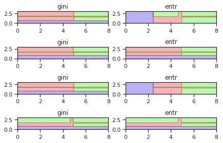

```python
for i in range(4):
    plt.subplot(4,2,2*i+1)
    train_sample = train.sample(100)
    y_train_sample = pd.factorize(train_sample['species'],sort='unique')[0]


    clf = tree.DecisionTreeClassifier(criterion='gini')
    clf = clf.fit(train_sample[features[2:]], y_train_sample)
    prediction_grille = clf.predict(grille_2D)
    plt.contourf(X_pl,Y_pw,prediction_grille.reshape(300,300),cmap='brg',alpha = 0.3)
    plt.title ("gini")
    print("[GINI] accuracy on the  test set   ", clf.score(test[features[2:]], y_test))

    plt.subplot(4,2,2*i+2)
    clf = tree.DecisionTreeClassifier(criterion='entropy')
    clf = clf.fit(train_sample[features[2:]], y_train_sample)
    prediction_grille = clf.predict(grille_2D)
    plt.contourf(X_pl,Y_pw,prediction_grille.reshape(300,300),cmap='brg',alpha = 0.3)
    plt.title("entr")
    print("[ENTR] accuracy on the  test set   ", clf.score(test[features[2:]], y_test))
plt.tight_layout()
```

###### Let's try the robustness of those criterion : we drop some samples of some classes and see if it affects the accuracy

Let's drop some examples of setosa, to create a unbalanced training set with respect to setosa

```
Number of setosa: 39
[GINI] accuracy on the  test set    0.868421052631579
[ENTR] accuracy on the  test set    0.868421052631579
Number of setosa: 30
[GINI] accuracy on the  test set    0.868421052631579
[ENTR] accuracy on the  test set    0.868421052631579
Number of setosa: 22
[GINI] accuracy on the  test set    0.868421052631579
[ENTR] accuracy on the  test set    0.868421052631579
Number of setosa: 12
[GINI] accuracy on the  test set    0.868421052631579
[ENTR] accuracy on the  test set    0.868421052631579
Number of setosa: 1
[GINI] accuracy on the  test set    0.8421052631578947
[ENTR] accuracy on the  test set    0.868421052631579
Number of setosa: 0
[GINI] accuracy on the  test set    0.2631578947368421
[ENTR] accuracy on the  test set    0.2631578947368421
```

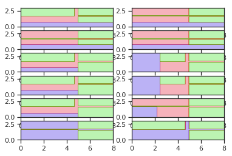

```python
for i in range(6):
    plt.subplot(6,2,2*i+1)
    train_sample = train.drop(train[train.index<=i*12].index)
    print("Number of setosa:",len(train_sample[train_sample.species=="setosa"]))
    y_train_sample = pd.factorize(train_sample['species'],sort='unique')[0]


    clf = tree.DecisionTreeClassifier(criterion='gini')
    clf = clf.fit(train_sample[features[2:]], y_train_sample)
    prediction_grille = clf.predict(grille_2D)
    plt.contourf(X_pl,Y_pw,prediction_grille.reshape(300,300),cmap='brg',alpha = 0.3)

    print("[GINI] accuracy on the  test set   ", clf.score(test[features[2:]], y_test))

    plt.subplot(6,2,2*i+2)
    clf = tree.DecisionTreeClassifier(criterion='entropy')
    clf = clf.fit(train_sample[features[2:]], y_train_sample)
    prediction_grille = clf.predict(grille_2D)
    plt.contourf(X_pl,Y_pw,prediction_grille.reshape(300,300),cmap='brg',alpha = 0.3)

    print("[ENTR] accuracy on the  test set   ", clf.score(test[features[2:]], y_test))
```

The decision boundaries between the two criterion are different but the accuracy is almost always the same. However, sometimes, cross entropy criterion performs slightly better (run the cell many times: sometimes, for number of setosa = 1, we have GINI : 84%, ENTR: 86%): cross entropy might be slightly more robust. But those results are not enough to conclude that cross entropy is more robust in general, it might just be luck.  
Dropping samples of setosa almost does not affect the accuracy.

setosa is quite easily separable from the other classes as seen in the figure showing the petal length feature. Therefore, one sample might be enough to draw a correct decision boundary to differentiate setosa, therefore the accuracy is still quite good even with 1 sample of setosa.

Let's see if the classifier is still robust if we drop samples of virginica

```
Number of virginica: 0
[GINI] accuracy on the  test set    0.5
[ENTR] accuracy on the  test set    0.5
Number of virginica: 2
[GINI] accuracy on the  test set    0.7368421052631579
[ENTR] accuracy on the  test set    0.7368421052631579
Number of virginica: 6
[GINI] accuracy on the  test set    0.7368421052631579
[ENTR] accuracy on the  test set    0.7368421052631579
Number of virginica: 10
[GINI] accuracy on the  test set    0.8421052631578947
[ENTR] accuracy on the  test set    0.8421052631578947
Number of virginica: 14
[GINI] accuracy on the  test set    0.8421052631578947
[ENTR] accuracy on the  test set    0.868421052631579
```

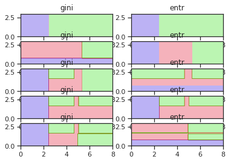

```python
for i in range(5):
    plt.subplot(5,2,2*i+1)
    train_sample = train.drop(train[train.index>99 + 5*i].index)
    print("Number of virginica:",len(train_sample[train_sample.species=="virginica"]))
    y_train_sample = pd.factorize(train_sample['species'],sort='unique')[0]


    clf = tree.DecisionTreeClassifier(criterion='gini')
    clf = clf.fit(train_sample[features[2:]], y_train_sample)
    prediction_grille = clf.predict(grille_2D)
    plt.contourf(X_pl,Y_pw,prediction_grille.reshape(300,300),cmap='brg',alpha = 0.3)
    plt.title ("gini")
    print("[GINI] accuracy on the  test set   ", clf.score(test[features[2:]], y_test))

    plt.subplot(5,2,2*i+2)
    clf = tree.DecisionTreeClassifier(criterion='entropy')
    clf = clf.fit(train_sample[features[2:]], y_train_sample)
    prediction_grille = clf.predict(grille_2D)
    plt.contourf(X_pl,Y_pw,prediction_grille.reshape(300,300),cmap='brg',alpha = 0.3)
    plt.title("entr")
    print("[ENTR] accuracy on the  test set   ", clf.score(test[features[2:]], y_test))
```

Again, the model is quite robust, although we see that for 6 samples of virginica, the accuracy had already decreased. (for setosa, even with 1 single sample, we had almost the same accuracy than with 40 samples).  
Again, for 14 samples of virginica, sometimes, cross entropy accuracy is also better (86%) compared to gini (84%).

### Going further ahead (not mandatory)

Try the same approach adapted to another toy dataset from `scikit-learn` described at: http://scikit-learn.org/stable/datasets/index.html

Play with another dataset available at: http://archive.ics.uci.edu/ml/datasets.html

=====> Cf end of TP

## Step 4: Random forests

Go to

http://scikit-learn.org/stable/modules/generated/sklearn.ensemble.RandomForestClassifier.html

for a documentation about the `RandomForestClassifier` provided by `scikit-learn`.

Since target values must be integers, we first need to transform labels into numbers as below.

```python
# train['species'] contains the actual species names. Before we can use it,
# we need to convert each species name into a digit. So, in this case there
# are three species, which have been coded as 0, 1, or 2.
y = pd.factorize(train['species'])[0]

# View target
y
```

```
array([0, 0, 0, 0, 0, 0, 0, 0, 0, 0, 0, 0, 0, 0, 0, 0, 0, 0, 0, 0, 0, 0,
       0, 0, 0, 0, 0, 0, 0, 0, 0, 0, 0, 0, 0, 0, 0, 0, 0, 0, 1, 1, 1, 1,
       1, 1, 1, 1, 1, 1, 1, 1, 1, 1, 1, 1, 1, 1, 1, 1, 1, 1, 1, 1, 1, 1,
       1, 1, 1, 1, 1, 1, 1, 1, 1, 1, 1, 1, 1, 1, 1, 2, 2, 2, 2, 2, 2, 2,
       2, 2, 2, 2, 2, 2, 2, 2, 2, 2, 2, 2, 2, 2, 2, 2, 2, 2, 2, 2, 2, 2,
       2, 2])
```

```python
# Create a random forest Classifier. By convention, clf means 'Classifier'
rf = RandomForestClassifier(n_jobs=2, random_state=0)

# Train the Classifier to take the training features and learn how they relate
# to the training y (the species)
rf.fit(train[features], y)
```

```
RandomForestClassifier(bootstrap=True, class_weight=None, criterion='gini',
            max_depth=None, max_features='auto', max_leaf_nodes=None,
            min_impurity_decrease=0.0, min_impurity_split=None,
            min_samples_leaf=1, min_samples_split=2,
            min_weight_fraction_leaf=0.0, n_estimators=10, n_jobs=2,
            oob_score=False, random_state=0, verbose=0, warm_start=False)
```

**Make predictions** and create actual english names for the plants for each predicted plant class:

```python
preds = rf.predict(test[features])
preds_names = pd.Categorical.from_codes(preds, iris.target_names)
preds_names
```

[output not shown]

### Create a confusion matrix

```python
# Create confusion matrix unsing pandas:
pd.crosstab(test['species'], preds, rownames=['Actual Species'], colnames=['Predicted Species'])
```

| Predicted Species Actual Species | 0 | 1 | 2 |
| --- | --- | --- | --- |
| setosa | 10 | 0 | 0 |
| versicolor | 0 | 9 | 0 |
| virginica | 0 | 1 | 18 |

## Feature selection using random forests byproducts

One of the interesting use cases for random forest is feature selection. One of the byproducts of trying lots of decision tree variations is that you can examine which variables are working best/worst in each tree.

When a certain tree uses one variable and another doesn't, you can compare the value lost or gained from the inclusion/exclusion of that variable. The good random forest implementations are going to do that for you, so all you need to do is know which method or variable to look at.

### View feature importance

While we don't get regression coefficients like with ordinary least squares (OLS), we do get a score telling us how important each feature was in classifying. This is one of the most powerful parts of random forests, because we can clearly see that petal width was more important in classification than sepal width.

```python
# View a list of the features and their importance scores
list(zip(train[features], rf.feature_importances_))
```

```
[('sepal length (cm)', 0.13313710938050363),
 ('sepal width (cm)', 0.03292918868346942),
 ('petal length (cm)', 0.299290321517918),
 ('petal width (cm)', 0.5346433804181089)]
```

```python
len(y_train)
```

```
101
```

As see previously, the petals features are more important than the peatals features.  
But we also see/learn that "sepal length" are more important than "sepal width". And that "petal width" are more important than "petal length".

## Exercise 3

1. Comment on the feature importances with respect to your previous observations on decision trees above.
2. Extract and visualize 5 trees belonging to the random forest using the attribute `estimators_` of the trained random forest classifier. Compare them. *Note that you may code a loop on extracted trees.*
3. Study the influence of parameters like `max_depth`, `min_samples_leaf` and `min_samples_split`. Try to optimize them and explain your approach and choices.
4. How is estimated the prediction error of a random forest ? *Indication: have a look at parameter `oob_score`.* What are out-of-bag samples ?
5. What should you do when classes are not balanced in the dataset ? (that is when there are much more examples of one class than another)

```python
@interact(est=[0,1,2,3,4])
def view(est):
    clf = rf.estimators_[est]
    dot_data = tree.export_graphviz(clf, out_file=None,
                         feature_names=iris.feature_names,
                         class_names=iris.target_names,
                         filled=True, rounded=True,
                         special_characters=True)
    return graphviz.Source(dot_data)
```

### Hyper-parameter optimization

```python
dict_param = {'max_depth':[1,2,3,10],
            'min_samples_leaf':[1,10,30],
            'min_samples_split':[2,3,10,20],
             'oob_score':True,
             'nb_tree':[0,1,2,3,4]}
@interact(**dict_param)
def explore(max_depth, min_samples_leaf, min_samples_split, oob_score, nb_tree):
    input_dic = {'max_depth':max_depth,
            'min_samples_leaf':min_samples_leaf,
            'min_samples_split':min_samples_split,
             'oob_score':oob_score}
    clf = RandomForestClassifier(n_jobs=2, random_state=0, **input_dic)
    clf.fit(train[features], y)
    dot_data = tree.export_graphviz(clf.estimators_[nb_tree], out_file=None,
                             feature_names=iris.feature_names,
                             class_names=iris.target_names,
                             filled=True, rounded=True,
                             special_characters=True)
    return graphviz.Source(dot_data)
```

The parameters max_depth, min_samples_leaf and min_samples_split affects the stopping criterion.  
If the algorithm stop earlier, the tree is smaller and simpler.  
By tunning the parameter, we can make better prediction (tree too small) and avoid overfitting (tree too large).

#### Cross Validation

We use cross validation to tunning the criterions

```python
shuffle_train = train.sample(frac=1)
shuffle_train['species'] =  pd.factorize(shuffle_train['species'],sort='unique')[0]
set_size = train.shape[0]
K = 10
n = set_size//K

val_max_depth = [1,2,3,4,5,6,7,8,9]
val_min_samples_leaf = [1,5,10,20,40]
val_min_samples_split = [2,5,10,20,40]

moy_vals = np.zeros((len(val_max_depth),
                    len(val_min_samples_leaf),
                    len(val_min_samples_split)))

for l in range(K):
    train_set = np.vstack((shuffle_train.values[:l*n],shuffle_train.values[(l+1)*n:]))
    validation_set = shuffle_train.values[l*n:(l+1)*n]
    train_set = train_set.astype(np.float64)
    validation_set = validation_set.astype(np.float64)

    X_train, y_train = train_set[:,:4],train_set[:,4]
    X_validation, y_validation = validation_set[:,:4],validation_set[:,4]

    for i in range(len(val_max_depth)):
        for j in range(len(val_min_samples_leaf)):
            for k in range(len(val_min_samples_split)):
                dict_param = {'max_depth':val_max_depth[i],
                              'min_samples_leaf':val_min_samples_leaf[j],
                             'min_samples_split':val_min_samples_split[k]}
                clf = RandomForestClassifier(n_jobs=2, random_state=0,**dict_param)
                clf.fit(X_train, y_train)
                moy_vals[i,j,k] += clf.score(X_validation, y_validation)
    print(l)
moy_vals /= K
```

```
0
1
2
3
4
5
6
7
8
9
```

```
Text(0.5,1,'accuracy % min_samples_split')
```

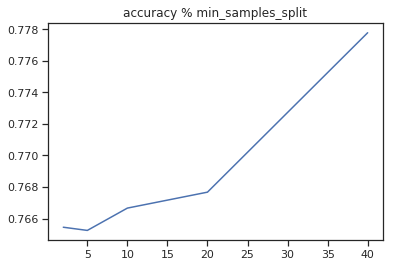

```python
plt.plot(val_min_samples_split,moy_vals.mean(axis=0).mean(axis=0))
plt.title("accuracy % min_samples_split")
```

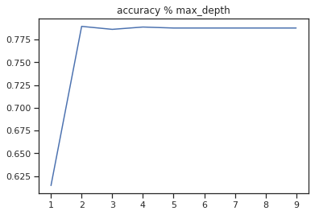

```python
plt.plot(val_max_depth,moy_vals.mean(axis=2).mean(axis=1))
plt.title("accuracy % max_depth");
```

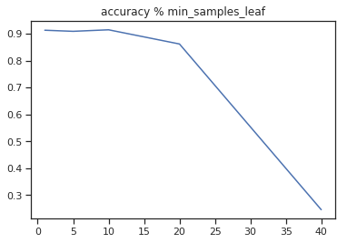

```python
plt.plot(val_min_samples_leaf,moy_vals.mean(axis=0).mean(axis=1))
plt.title("accuracy % min_samples_leaf");
```

```python
max_depth_opt = 4
min_samples_split_opt = 20
min_samples_leaf_opt=1

input_dic = {'max_depth':max_depth_opt,
            'min_samples_leaf':min_samples_leaf_opt,
            'min_samples_split':min_samples_split_opt,
             }
clf = RandomForestClassifier(n_jobs=2, random_state=0, **input_dic)
clf.fit(train[features], y)

print(clf.score(test[features],y_test))
```

```
1.0
```

### Oob error

to compute the error on a random forest classifier we can use oob error (Out Of Bag Error)  
OOB is the mean prediction error on each training sample xᵢ, using only the trees that did not have xᵢ in their bootstrap sample. (wikipedia)  
This allows to give an estimation of the error of generalization without using a test set.

```python
max_depth_opt = 1
min_samples_split_opt = 20
min_samples_leaf_opt=20
oob_score=True

input_dic = {'max_depth':max_depth_opt,
            'min_samples_leaf':min_samples_leaf_opt,
            'min_samples_split':min_samples_split_opt,
            'oob_score':oob_score}
clf = RandomForestClassifier(n_jobs=2, random_state=0, **input_dic)
clf.fit(train[features], y)
print("OOB score:",clf.oob_score_)
print("Test set :",clf.score(test[features],y_test))
```

```
OOB score: 0.7142857142857143
Test set : 0.5
```

### Dealing with unbalanced data

To deal with unbalanced data, we can resampling our dataset. We can sample each classes separately and in this way choose the same number of sample in each classes.  
In scikit-learn we can simply choose class_weight = 'balanced' which will adjust weights automatically.

## Step 5: a small example of regression using random forests

Random forest is capable of learning without carefully crafted data transformations. Take the the $f(x) = \sin(x)$ function for example.

Create some fake data and add a little noise.

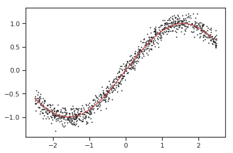

```python
x = np.random.uniform(-2.5, 2.5, 1000)
y = np.sin(x) + np.random.normal(0, .1, 1000)

plt.plot(x,y,'ko',markersize=1,label='data')
plt.plot(np.arange(-2.5,2.5,0.1),np.sin(np.arange(-2.5,2.5,0.1)),'r-',label='ref')
plt.show()
```

If we try and build a basic linear model to predict y using x we end up with a straight line that sort of bisects the sin(x) function. Whereas if we use a random forest, it does a much better job of approximating the sin(x) curve and we get something that looks much more like the true function.

Based on this example, we will illustrate how the random forest isn't bound by linear constraints.

## Exercise 4

1. Apply random forests on this dataset for regression and compare performances with ordinary least squares regression. *Note that ordinay least square regression is available thanks to: from sklearn.linear_model import LinearRegression*
2. Comment on your results.

### Indications:

You may use half of points for training and others to test predictions. Then you will have an idea of how far the random forest predictor fits the sinus curve.

To this aim, you will need to use the model `RandomForestRegressor`. Be careful that when only 1 feature `x` is used as an input, you will need to reshape it by `x.reshape(-1,1)` when using methods `fit` and `predict`.

```
training error 0.980
test error 0.972
distance error from ubiased data : 8.641236593048713
```

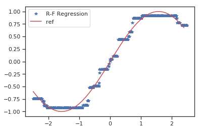

```python
regrf = RandomForestRegressor(n_estimators=5, max_depth=3)
# Train on even indices dataset
regrf.fit(x[0::2].reshape(-1, 1),y[0::2])
# We predict on test dataset (odd indices)
plt.plot(x[1::2],regrf.predict(x[1::2].reshape((-1,1))),'*',label="R-F Regression")
plt.plot(np.arange(-2.5,2.5,0.1),np.sin(np.arange(-2.5,2.5,0.1)),'r-',label='ref')
print(f"training error {regrf.score(x[0::2].reshape((-1,1)), y[0::2]) :.3f}")
print(f"test error {regrf.score(x[1::2].reshape((-1,1)), y[1::2]) :.3f}")
print(f"distance error from ubiased data : {np.sum((regrf.predict(x[1::2].reshape((-1,1)))- y[1::2])**2)}")
plt.legend()
```

If we use a tree for regression we will approximate the function with a step function, each leave of the tree correspond to one step.  
The number of leaves of the tree, is majored by $2^{max\_depth}$  
Also if we increase the number of leaves, the tree become more precise, but max_depth should not be not big to avoid overfitting.

#### Tree regression

```
******** USING max_depth=1************
training error 0.841
test error 0.866
distance error from ubiased data : 41.856184550773534
******** USING max_depth=2************
training error 0.952
test error 0.953
distance error from ubiased data : 14.731049024995183
******** USING max_depth=4************
training error 0.983
test error 0.977
distance error from ubiased data : 7.0511066258876465
******** USING max_depth=20************
training error 0.987
test error 0.967
distance error from ubiased data : 10.333277453007277
```

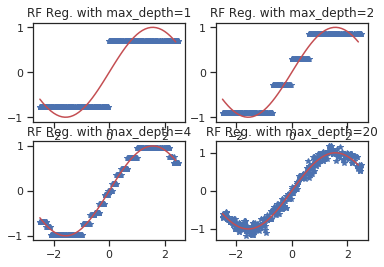

```python
max_d_list = [1,2,4,20]
for i in range(0,len(max_d_list)):
    plt.subplot(2,2,i+1)
    regrf = RandomForestRegressor(n_estimators=1, max_depth=max_d_list[i])
    # Train on even indices dataset
    regrf.fit(x[0::2].reshape(-1, 1),y[0::2])
    # We predict on test dataset (odd indices)
    plt.plot(x[1::2],regrf.predict(x[1::2].reshape((-1,1))),'*',label="R-F Regression")
    plt.plot(np.arange(-2.5,2.5,0.1),np.sin(np.arange(-2.5,2.5,0.1)),'r-',label='ref')
    plt.title(f"RF Reg. with max_depth={max_d_list[i]}")
    print(f"******** USING max_depth={max_d_list[i]}************")
    print(f"training error {regrf.score(x[0::2].reshape((-1,1)), y[0::2]) :.3f}")
    print(f"test error {regrf.score(x[1::2].reshape((-1,1)), y[1::2]) :.3f}")
    print(f"distance error from ubiased data : {np.sum((regrf.predict(x[1::2].reshape((-1,1)))- y[1::2])**2)}")
```

We can see with the three first graph, that if tree are more deeper they can better approximate the function.  
In the last graph, the tree has overfit the data, and then have touble approaching the curve.

#### Random Forest Regression

Random-Forest predictor are build with severals tree regressor.  
In our case, we have only 1 feature. Also the only differences between the trees in the Forest is the dataset using for training.  
Also, there is no great differences between the tree, their differ only sightly on the threshold, using to split the node. This make that the predicted function is smoother.

```
******** USING n_estimators=1************
training error 0.952
test error 0.950
distance error from ubiased data : 15.688
******** USING n_estimators=2************
training error 0.954
test error 0.950
distance error from ubiased data : 15.592
******** USING n_estimators=4************
training error 0.964
test error 0.959
distance error from ubiased data : 12.678
******** USING n_estimators=10************
training error 0.964
test error 0.961
distance error from ubiased data : 12.159
```

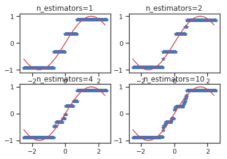

```python
n_estimators_list = [1,2,4,10]
for i in range(0,len(n_estimators_list)):
    plt.subplot(2,2,i+1)
    regrf = RandomForestRegressor(n_estimators=n_estimators_list[i], max_depth=2)
    # Train on even indices dataset
    regrf.fit(x[0::2].reshape(-1, 1),y[0::2])
    # We predict on test dataset (odd indices)
    plt.plot(x[1::2],regrf.predict(x[1::2].reshape((-1,1))),'*',label="R-F Regression")
    plt.plot(np.arange(-2.5,2.5,0.1),np.sin(np.arange(-2.5,2.5,0.1)),'r-',label='ref')
    plt.title(f"n_estimators={n_estimators_list[i]}")
    print(f"******** USING n_estimators={n_estimators_list[i]}************")
    print(f"training error {regrf.score(x[0::2].reshape((-1,1)), y[0::2]) :.3f}")
    print(f"test error {regrf.score(x[1::2].reshape((-1,1)), y[1::2]) :.3f}")
    print(f"distance error from ubiased data : {np.sum((regrf.predict(x[1::2].reshape((-1,1)))- y[1::2])**2):.3f}")
```

We see that by increase the number of estimators, the functions stay quite the same. But the steps are smoother.

With the previous results, we can expect to have great results with : $n\_estimators=10, max\_depth=5$ (for example)

```
training error 0.987
test error 0.980
distance error from ubiased data : 6.180
```

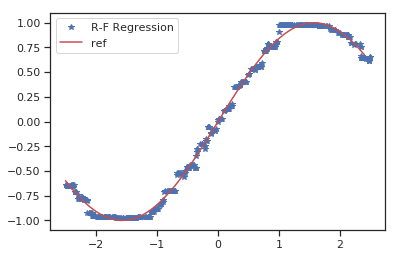

```python
regrf = RandomForestRegressor(n_estimators=10, max_depth=5)
# Train on even indices dataset
regrf.fit(x[0::2].reshape(-1, 1),y[0::2])
# We predict on test dataset (odd indices)
plt.plot(x[1::2],regrf.predict(x[1::2].reshape((-1,1))),'*',label="R-F Regression")
plt.plot(np.arange(-2.5,2.5,0.1),np.sin(np.arange(-2.5,2.5,0.1)),'r-',label='ref')
print(f"training error {regrf.score(x[0::2].reshape((-1,1)), y[0::2]) :.3f}")
print(f"test error {regrf.score(x[1::2].reshape((-1,1)), y[1::2]) :.3f}")
print(f"distance error from ubiased data : {np.sum((regrf.predict(x[1::2].reshape((-1,1)))- y[1::2])**2):.3f}")

plt.legend()
```

#### Linear Regression

If we use linear regression with only the first feature, we will have obviously a big error when estimating the sinus function.

```
training error 0.858
test error 0.846
distance error from ubiased data : 48.083
```

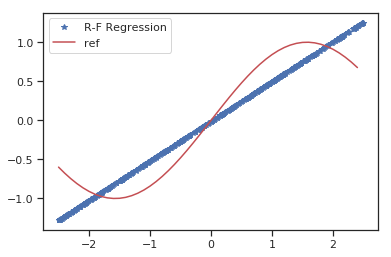

```python
from sklearn.linear_model import LinearRegression
regrf = LinearRegression()
regrf.fit((x[0::2]).reshape(-1, 1),y[0::2])
plt.plot(x[1::2],regrf.predict((x[1::2]).reshape((-1,1))),'*',label="R-F Regression")
plt.plot(np.arange(-2.5,2.5,0.1),np.sin(np.arange(-2.5,2.5,0.1)),'r-',label='ref')
plt.legend()
print(f"training error {regrf.score(x[0::2].reshape((-1,1)), y[0::2]) :.3f}")
print(f"test error {regrf.score(x[1::2].reshape((-1,1)), y[1::2]) :.3f}")
print(f"distance error from ubiased data : {np.sum((regrf.predict(x[1::2].reshape((-1,1)))- y[1::2])**2):.3f}")
```

First we can use features augmantation to make polynomial regression

```
(1000, 2)
******** USING degré =2************
training error 0.858
test error 0.846
distance error from ubiased data : 48.172
(1000, 3)
******** USING degré =3************
training error 0.984
test error 0.981
distance error from ubiased data : 5.930
(1000, 4)
******** USING degré =4************
training error 0.984
test error 0.981
distance error from ubiased data : 5.976
(1000, 5)
******** USING degré =5************
training error 0.984
test error 0.982
distance error from ubiased data : 5.583
```

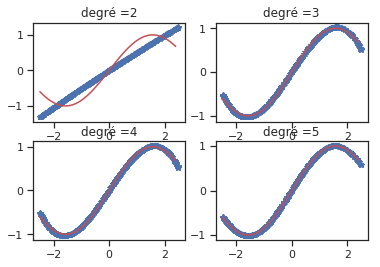

```python
x_aug = x.copy().reshape((-1,1))
deg_list = [2,3,4,5]
point_deg = 0
for i in range(2,deg_list[-1]+1):
    x_aug = np.hstack((x_aug,x_aug[:,0].reshape((-1,1))**i))
    if i == deg_list[point_deg]:
        print(x_aug.shape)
        plt.subplot(2,2,point_deg+1)
        regln = LinearRegression()
        # Train on even indices dataset
        regln.fit(x_aug[0::2],y[0::2])
        # We predict on test dataset (odd indices)
        plt.plot(x[1::2],regln.predict(x_aug[1::2]),'*',label="R-F Regression")
        plt.plot(np.arange(-2.5,2.5,0.1),np.sin(np.arange(-2.5,2.5,0.1)),'r-',label='ref')
        plt.title(f"degré ={deg_list[point_deg]}")
        print(f"******** USING degré ={deg_list[point_deg]}************")
        print(f"training error {regln.score(x_aug[0::2], y[0::2]) :.3f}")
        print(f"test error {regln.score(x_aug[1::2], y[1::2]) :.3f}")
        print(f"distance error from ubiased data : {np.sum((regln.predict(x_aug[1::2])- y[1::2])**2) :.3f}")

        point_deg += 1
```

With polynome degree > 2, the linear regression perfom sligthy better than the Random Forest Regression.

```
training error 0.984
test error 0.983
distance error from ubiased data : 5.087
```

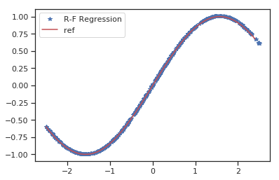

```python
x_aug = x.copy().reshape((-1,1))
x_aug = np.hstack((x_aug,np.sin(x_aug)))
regln = LinearRegression()
regln.fit(x_aug[0::2],y[0::2])
plt.plot(x[1::2],regln.predict(x_aug[1::2]),'*',label="R-F Regression")
plt.plot(np.arange(-2.5,2.5,0.1),np.sin(np.arange(-2.5,2.5,0.1)),'r-',label='ref')
plt.legend()
print(f"training error {regln.score(x_aug[0::2], y[0::2]) :.3f}")
print(f"test error {regln.score(x_aug[1::2], y[1::2]) :.3f}")
print(f"distance error from ubiased data : {np.sum((regln.predict(x_aug[1::2])- y[1::2])**2):.3f}")
```

When using only the features data, the RF perform well better than the Linear Model.  
But in this simple case, we can use features augmantation to obtain good result with Linear Regression.

### Indication

One clever way to compare models when using `scikit-learn`is to make a loop on models as follows:

```python
max_depth_opt = 10
min_samples_split_opt = 10
min_samples_leaf_opt=10

input_dic = {'max_depth':max_depth_opt,
            'min_samples_leaf':min_samples_leaf_opt,
            'min_samples_split':min_samples_split_opt,
             }
clf = RandomForestClassifier(n_jobs=2, random_state=0, **input_dic)
models = [tree.DecisionTreeClassifier(max_depth=None), clf]
for model in models:
    model.fit(train[features],y_train)
    print(model.score(test[features],y_test))
```

```
0.8709677419354839
0.9354838709677419
```

## Pruning trees: not available in scikit-learn.

Since post-pruning of tree is not implemented in scikit-learn, you may think of coding your own pruning function. For instance, taking into account the numer of samples per leaf as proposed below:

```python
# Pruning function (useful ?)
def prune(decisiontree, min_samples_leaf = 1):
    if decisiontree.min_samples_leaf >= min_samples_leaf:
        raise Exception('Tree already more pruned')
    else:
        decisiontree.min_samples_leaf = min_samples_leaf
        tree = decisiontree.tree_
        for i in range(tree.node_count):
            n_samples = tree.n_node_samples[i]
            if n_samples <= min_samples_leaf:
                tree.children_left[i]=-1
                tree.children_right[i]=-1
```

[output not shown]

# Other dataset

## Load and prepare dataset

```python
from sklearn.datasets import load_wine
wine = load_wine()
#data.target[[10, 80, 140]]
df_wine = pd.DataFrame(wine.data,columns=wine.feature_names)
```

```python
df_wine.head()
df_wine['class'] = pd.Categorical.from_codes(wine.target, wine.target_names)
```

```python
df_wine.head()
```

|  | alcohol | malic_acid | ash | alcalinity_of_ash | magnesium | total_phenols | flavanoids | nonflavanoid_phenols | proanthocyanins | color_intensity | hue | od280/od315_of_diluted_wines | proline | class |
| --- | --- | --- | --- | --- | --- | --- | --- | --- | --- | --- | --- | --- | --- | --- |
| 0 | 14.23 | 1.71 | 2.43 | 15.6 | 127.0 | 2.80 | 3.06 | 0.28 | 2.29 | 5.64 | 1.04 | 3.92 | 1065.0 | class_0 |
| 1 | 13.20 | 1.78 | 2.14 | 11.2 | 100.0 | 2.65 | 2.76 | 0.26 | 1.28 | 4.38 | 1.05 | 3.40 | 1050.0 | class_0 |
| 2 | 13.16 | 2.36 | 2.67 | 18.6 | 101.0 | 2.80 | 3.24 | 0.30 | 2.81 | 5.68 | 1.03 | 3.17 | 1185.0 | class_0 |
| 3 | 14.37 | 1.95 | 2.50 | 16.8 | 113.0 | 3.85 | 3.49 | 0.24 | 2.18 | 7.80 | 0.86 | 3.45 | 1480.0 | class_0 |
| 4 | 13.24 | 2.59 | 2.87 | 21.0 | 118.0 | 2.80 | 2.69 | 0.39 | 1.82 | 4.32 | 1.04 | 2.93 | 735.0 | class_0 |

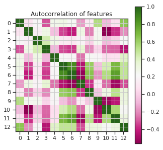

```python
correlations = df_wine.corr()
fig = plt.figure(figsize = (5,5))
ax = fig.add_subplot(1, 1, 1)

plt.imshow(correlations,cmap='PiYG')
#plt.imshow(correlations,cmap='viridis')
plt.colorbar()
plt.grid(b=1)
plt.title("Autocorrelation of features")
a = ax.set_xticks(np.arange(correlations.shape[0]))
a = ax.set_yticks(np.arange(correlations.shape[0]))
```

```python
df_wine['is_train'] = np.random.uniform(0, 1, len(df_wine)) <= .75
df_wine.head()
```

|  | alcohol | malic_acid | ash | alcalinity_of_ash | magnesium | total_phenols | flavanoids | nonflavanoid_phenols | proanthocyanins | color_intensity | hue | od280/od315_of_diluted_wines | proline | class | is_train |
| --- | --- | --- | --- | --- | --- | --- | --- | --- | --- | --- | --- | --- | --- | --- | --- |
| 0 | 14.23 | 1.71 | 2.43 | 15.6 | 127.0 | 2.80 | 3.06 | 0.28 | 2.29 | 5.64 | 1.04 | 3.92 | 1065.0 | class_0 | False |
| 1 | 13.20 | 1.78 | 2.14 | 11.2 | 100.0 | 2.65 | 2.76 | 0.26 | 1.28 | 4.38 | 1.05 | 3.40 | 1050.0 | class_0 | True |
| 2 | 13.16 | 2.36 | 2.67 | 18.6 | 101.0 | 2.80 | 3.24 | 0.30 | 2.81 | 5.68 | 1.03 | 3.17 | 1185.0 | class_0 | False |
| 3 | 14.37 | 1.95 | 2.50 | 16.8 | 113.0 | 3.85 | 3.49 | 0.24 | 2.18 | 7.80 | 0.86 | 3.45 | 1480.0 | class_0 | True |
| 4 | 13.24 | 2.59 | 2.87 | 21.0 | 118.0 | 2.80 | 2.69 | 0.39 | 1.82 | 4.32 | 1.04 | 2.93 | 735.0 | class_0 | True |

```python
train_w, test_w = df_wine[df_wine['is_train']==True], df_wine[df_wine['is_train']==False]
```

```python
print('Number of observations in the training data:', len(train_w))
print('Number of observations in the test data:',len(test_w))
```

```
Number of observations in the training data: 133
Number of observations in the test data: 45
```

```python
features_w = df_wine.columns[:-2]
features_w
```

```
Index(['alcohol', 'malic_acid', 'ash', 'alcalinity_of_ash', 'magnesium',
       'total_phenols', 'flavanoids', 'nonflavanoid_phenols',
       'proanthocyanins', 'color_intensity', 'hue',
       'od280/od315_of_diluted_wines', 'proline'],
      dtype='object')
```

```python
y_train_w = pd.factorize(train_w['class'])[0]
y_test_w = pd.factorize(test_w['class'])[0]
print("Number of class in train set 0: ",len(y_train_w[y_train_w==0]))
print("Number of class in train set 1: ",len(y_train_w[y_train_w==1]))
print("Number of class in train set 2: ",len(y_train_w[y_train_w==2]))

print("Number of class in test set 0: ",len(y_test_w[y_test_w==0]))
print("Number of class in test set 1: ",len(y_test_w[y_test_w==1]))
print("Number of class in test set 2: ",len(y_test_w[y_test_w==2]))
print(y_train_w.shape,y_test_w.shape)
```

```
Number of class in train set 0:  42
Number of class in train set 1:  49
Number of class in train set 2:  42
Number of class in test set 0:  17
Number of class in test set 1:  22
Number of class in test set 2:  6
(133,) (45,)
```

## Decision tree

```python
clf = tree.DecisionTreeClassifier()
clf = clf.fit(train_w[features_w],y_train_w)
```

```python
dot_data = tree.export_graphviz(clf, out_file=None,
                         feature_names=wine.feature_names,
                         class_names=wine.target_names,
                         filled=True, rounded=True,
                         special_characters=True)
graph = graphviz.Source(dot_data)
graph
```

[figure not shown]

```python
print("Accuracy train set: ",clf.score(train_w[features_w],y_train_w))
print("Accuracy test set: ", clf.score(test_w[features_w],y_test_w))
```

```
Accuracy train set:  1.0
Accuracy test set:  0.8888888888888888
```

LEt's drop some features which are irrelevant regarding this decision tree.

```python
new_train_w = train_w.drop(columns=['alcohol', 'malic_acid', 'ash','magnesium',
       'total_phenols','nonflavanoid_phenols',
       'proanthocyanins', 'hue',
       'od280/od315_of_diluted_wines'])
new_test_w = test_w.drop(columns=['alcohol', 'malic_acid', 'ash','magnesium',
       'total_phenols','nonflavanoid_phenols',
       'proanthocyanins', 'hue',
       'od280/od315_of_diluted_wines'])
new_y_train_w = pd.factorize(new_train_w['class'])[0]
new_y_test_w = pd.factorize(new_test_w['class'])[0]
new_features_w = new_train_w.columns[:-2]
new_features_w
```

```
Index(['alcalinity_of_ash', 'flavanoids', 'color_intensity', 'proline'], dtype='object')
```

```python
new_train_w.head()
```

|  | alcalinity_of_ash | flavanoids | color_intensity | proline | class | is_train |
| --- | --- | --- | --- | --- | --- | --- |
| 1 | 11.2 | 2.76 | 4.38 | 1050.0 | class_0 | True |
| 3 | 16.8 | 3.49 | 7.80 | 1480.0 | class_0 | True |
| 4 | 21.0 | 2.69 | 4.32 | 735.0 | class_0 | True |
| 6 | 14.6 | 2.52 | 5.25 | 1290.0 | class_0 | True |
| 7 | 17.6 | 2.51 | 5.05 | 1295.0 | class_0 | True |

```python
clf = tree.DecisionTreeClassifier()
clf = clf.fit(new_train_w[new_features_w],new_y_train_w)
print("Accuracy train set: ",clf.score(new_train_w[new_features_w],new_y_train_w))
print("Accuracy test set: ", clf.score(new_test_w[new_features_w],new_y_test_w))
```

```
Accuracy train set:  1.0
Accuracy test set:  0.9555555555555556
```

### Avoid overfitting with post-pruning tree

We're going to split our training set in a true training set and a validation set. Then, train our decision tree on the training set, and prune our decision tree so that we maximize the accuracy on validation set.

```python
train_w['is_val'] = np.random.uniform(0, 1, len(train_w)) <= .25

pruning_train,pruning_val = train_w[train_w['is_val']==False],train_w[train_w['is_val']==True]

pruning_y_train = y_train_w[train_w['is_val']==False]
pruning_y_val = y_train_w[train_w['is_val']==True]
```

```python
clf_pruning = tree.DecisionTreeClassifier()
clf_pruning.fit(pruning_train[features_w],pruning_y_train)
```

```
DecisionTreeClassifier(class_weight=None, criterion='gini', max_depth=None,
            max_features=None, max_leaf_nodes=None,
            min_impurity_decrease=0.0, min_impurity_split=None,
            min_samples_leaf=1, min_samples_split=2,
            min_weight_fraction_leaf=0.0, presort=False, random_state=None,
            splitter='best')
```

```python
dot_data = tree.export_graphviz(clf_pruning, out_file=None,
                         feature_names=wine.feature_names,
                         class_names=wine.target_names,
                         filled=True, rounded=True,
                         special_characters=True)
graph = graphviz.Source(dot_data)
graph
```

[figure not shown]

```python
print("Accuracy pruning train set: ",clf_pruning.score(pruning_train[features_w],pruning_y_train))
print("Accuracy validation set: ", clf_pruning.score(pruning_val[features_w],pruning_y_val))
print("Accuracy train set: ",clf_pruning.score(train_w[features_w],y_train_w))
print("Accuracy test set: ", clf_pruning.score(test_w[features_w],y_test_w))
```

```
Accuracy pruning train set:  1.0
Accuracy validation set:  0.8787878787878788
Accuracy train set:  0.9699248120300752
Accuracy test set:  0.9333333333333333
```

The tree has a perfect accuracy on training set, but not on test set. Let's see if we can improve the avoidance of overfitting with pruning

```python
# Pruning function (useful ?)
def prune(decisiontree, min_samples_leaf = 1):
    if decisiontree.min_samples_leaf >=min_samples_leaf:
        raise Exception('Tree already more pruned')
    else:
        decisiontree.min_samples_leaf = min_samples_leaf
        tree = decisiontree.tree_
        for i in range(tree.node_count):
            n_samples = tree.n_node_samples[i]
            if n_samples <= min_samples_leaf:
                tree.children_left[i]=-1
                tree.children_right[i]=-1
prune(clf_pruning,min_samples_leaf=45)
```

```python
dot_data = tree.export_graphviz(clf_pruning, out_file=None,
                         feature_names=wine.feature_names,
                         class_names=wine.target_names,
                         filled=True, rounded=True,
                         special_characters=True)
graph = graphviz.Source(dot_data)
graph
```

[figure not shown]

```python
print("Accuracy pruning train set: ",clf_pruning.score(pruning_train[features_w],pruning_y_train))
print("Accuracy validation set: ", clf_pruning.score(pruning_val[features_w],pruning_y_val))
print("Accuracy test set: ", clf_pruning.score(test_w[features_w],y_test_w))
```

```
Accuracy pruning train set:  0.95
Accuracy validation set:  0.8181818181818182
Accuracy test set:  0.9111111111111111
```

```python
param = 30
clf_pruning = tree.DecisionTreeClassifier()
clf_pruning.fit(pruning_train[features_w],pruning_y_train)
prune(clf_pruning,min_samples_leaf=param)
print("Accuracy pruning train set: ",clf_pruning.score(pruning_train[features_w],pruning_y_train))
print("Accuracy validation set: ", clf_pruning.score(pruning_val[features_w],pruning_y_val))
print("Accuracy test set: ", clf_pruning.score(test_w[features_w],y_test_w))
```

```
Accuracy pruning train set:  1.0
Accuracy validation set:  0.8787878787878788
Accuracy test set:  0.9333333333333333
```

Pruning may help to avoid overfitting, by cutting the tree and making it simpler.

## RandomForest

```python
rf = RandomForestClassifier(n_jobs=2, random_state=0)

# Train the Classifier to take the training features and learn how they relate
# to the training y (the species)
rf.fit(train_w[features_w], y_train_w)
```

```
RandomForestClassifier(bootstrap=True, class_weight=None, criterion='gini',
            max_depth=None, max_features='auto', max_leaf_nodes=None,
            min_impurity_decrease=0.0, min_impurity_split=None,
            min_samples_leaf=1, min_samples_split=2,
            min_weight_fraction_leaf=0.0, n_estimators=10, n_jobs=2,
            oob_score=False, random_state=0, verbose=0, warm_start=False)
```

```python
list(zip(train_w[features_w], rf.feature_importances_))
```

```
[('alcohol', 0.1230975556163955),
 ('malic_acid', 0.04983953166313888),
 ('ash', 0.0030602737367733286),
 ('alcalinity_of_ash', 0.03904361639719442),
 ('magnesium', 0.03873236951312211),
 ('total_phenols', 0.05877680284364443),
 ('flavanoids', 0.24041681244310728),
 ('nonflavanoid_phenols', 0.007719799814844959),
 ('proanthocyanins', 0.06147851263482146),
 ('color_intensity', 0.14074848247330585),
 ('hue', 0.052905503986334666),
 ('od280/od315_of_diluted_wines', 0.012905448584684856),
 ('proline', 0.17127529029263225)]
```

```python
max_depth_opt = 10
min_samples_split_opt = 2
min_samples_leaf_opt=1
oob_score=True

input_dic = {'max_depth':max_depth_opt,
            'min_samples_leaf':min_samples_leaf_opt,
            'min_samples_split':min_samples_split_opt,
            'oob_score':oob_score}
clf = RandomForestClassifier(n_jobs=2, random_state=0, **input_dic)
clf.fit(train_w[features_w], y_train_w)
print("OOB score:",clf.oob_score_)
print("Test set :",clf.score(test_w[features_w],y_test_w))
```

[output not shown]

The randomforest classifier performs perfectly on the test set. We should tune the hyperparameters with a cross validation but here for simplicity, we only tune it by hand.

### Feature selection

###### If we only take the relevant features obtained thanks to the randomforest classifier, and try with a decision tree

```python
new_train_w = train_w.drop(columns=['alcalinity_of_ash', 'malic_acid', 'ash','magnesium',
       'total_phenols','nonflavanoid_phenols',
       'proanthocyanins', 'hue',
       'od280/od315_of_diluted_wines'])
new_test_w = test_w.drop(columns=['alcalinity_of_ash', 'malic_acid', 'ash','magnesium',
       'total_phenols','nonflavanoid_phenols',
       'proanthocyanins', 'hue',
       'od280/od315_of_diluted_wines'])
new_y_train_w = pd.factorize(new_train_w['class'])[0]
new_y_test_w = pd.factorize(new_test_w['class'])[0]
new_features_w = new_train_w.columns[:-2]

clf = tree.DecisionTreeClassifier()
clf = clf.fit(new_train_w[new_features_w],new_y_train_w)
print("Accuracy train set: ",clf.score(new_train_w[new_features_w],new_y_train_w))
print("Accuracy test set: ", clf.score(new_test_w[new_features_w],new_y_test_w))
```

[output not shown]

We have a very good performance too

###### If we only take the relevant features obtained thanks to the randomforest classifier, and try with a random forest

```python
max_depth_opt = 10
min_samples_split_opt = 2
min_samples_leaf_opt=1
oob_score=True

input_dic = {'max_depth':max_depth_opt,
            'min_samples_leaf':min_samples_leaf_opt,
            'min_samples_split':min_samples_split_opt,
            'oob_score':oob_score}
clf = RandomForestClassifier(n_jobs=2, random_state=0, **input_dic)
clf.fit(new_train_w[new_features_w], new_y_train_w)
print("OOB score:",clf.oob_score_)
print("Test set :",clf.score(new_test_w[new_features_w],new_y_test_w))
```

```
OOB score: 0.9230769230769231
Test set : 0.9714285714285714
```

With less features, the OOB score is better. This might be because with less features, it's easier to generalize well, and not overfit the data.

## Other classifiers

### LDA, QDA

```python
from sklearn.discriminant_analysis import LinearDiscriminantAnalysis,QuadraticDiscriminantAnalysis
```

```python
clf_lda = LinearDiscriminantAnalysis()
clf_lda.fit(train_w[features_w], y_train_w)
print("Test set :",clf_lda.score(test_w[features_w],y_test_w))
clf_lda = LinearDiscriminantAnalysis()
clf_lda.fit(new_train_w[new_features_w],new_y_train_w)
print("Test set :",clf_lda.score(new_test_w[new_features_w],new_y_test_w))
```

```
Test set : 1.0
Test set : 0.9714285714285714
```

```python
clf_lda = QuadraticDiscriminantAnalysis()
clf_lda.fit(train_w[features_w], y_train_w)
print("Test set :",clf_lda.score(test_w[features_w],y_test_w))
clf_lda = QuadraticDiscriminantAnalysis()
clf_lda.fit(new_train_w[new_features_w],new_y_train_w)
print("Test set :",clf_lda.score(new_test_w[new_features_w],new_y_test_w))
```

```
Test set : 1.0
Test set : 1.0
```